# 20-job-level

`r`r library(tidyverse) library(ggplot2)

`r`r h1b_df <- DATA

soc_tech_14 <- h1b_df %>% filter(year == 2014) %>% filter(soc_field == 15) %>% group_by(employer_name) %>% summarise(n = n()) %>% arrange(-n) %>% ungroup

soc_tech_18 <- h1b_df %>% filter(year == 2018) %>% filter(soc_field == 15) %>% group_by(employer_name) %>% summarise(n = n()) %>% arrange(-n) %>% ungroup

soc_10_14 <- soc_tech_14 %>% top_n(15)

`r`r soc_10_18 <- soc_tech_18 %>% top_n(15)

`r`r soc_top <- as.vector(intersect(soc_10_14$employer_name,soc_10_18$employer_name)) soc_top

```
 [1] \infosys limited\                   \tata consultancy services limited\ \wipro limited\
 [4] \IBM\                               \deloitte consulting llp\           \accenture llp\
 [7] \Microsoft\                         \Google\                            \larsen & toubro infotech limited\
[10] \Amazon\
```

# overall

## high level analysis

`r`r highlevel_by_year <- DATA %>% group_by(year, job_level) %>% summarise(level_num = n())

highlevel_by_year

| year | job_level | level_num |
| --- | --- | --- |
| 2014 | high level | 80601 |
| 2014 | undefined | 429128 |
| 2015 | high level | 97485 |
| 2015 | undefined | 515540 |
| 2016 | high level | 97960 |
| 2016 | undefined | 545251 |
| 2017 | high level | 98780 |
| 2017 | undefined | 523908 |
| 2018 | high level | 118696 |
| 2018 | undefined | 534272 |

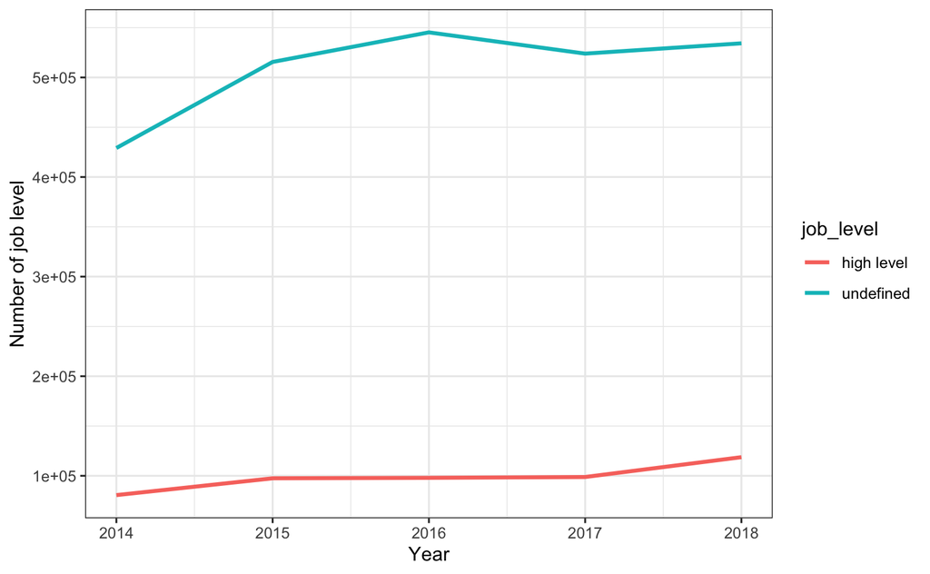

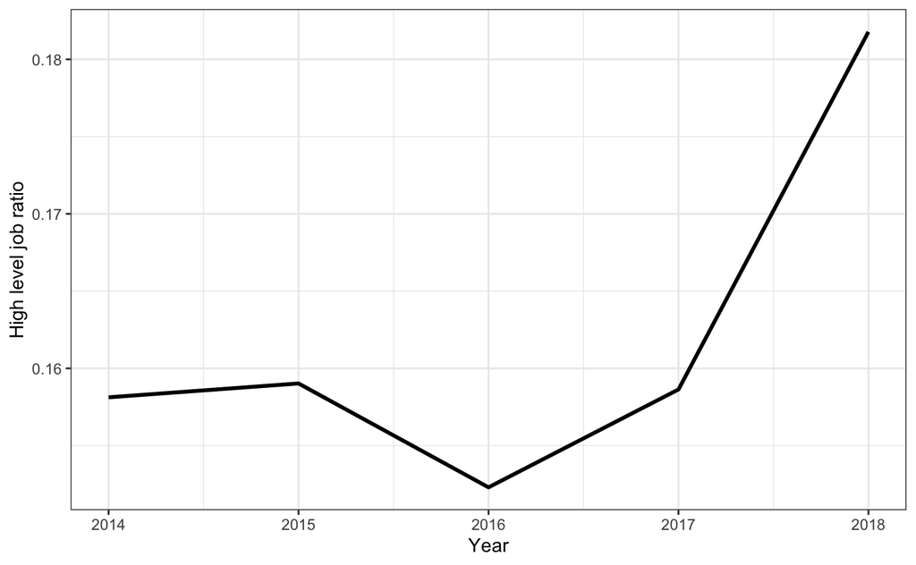

## data related analysis

`r`r data_related <- DATA %>% select(year, data_relation,job_title ) %>% arrange(-year) %>% group_by(year, data_relation) %>% summarise(type_sum = n())

data_related

| year | data_relation | type_sum |
| --- | --- | --- |
| 2014 | data_related | 56533 |
| 2014 | undefined | 453196 |
| 2015 | data_related | 70398 |
| 2015 | undefined | 542627 |
| 2016 | data_related | 76391 |
| 2016 | undefined | 566820 |
| 2017 | data_related | 76116 |
| 2017 | undefined | 546572 |
| 2018 | data_related | 85708 |
| 2018 | undefined | 567260 |

`r`r ggplot(data_related)+ geom_line(aes(x=year,y=type_sum,color=data_relation), size = 1.05)+ theme_bw()+ labs(x=, y=of job type)

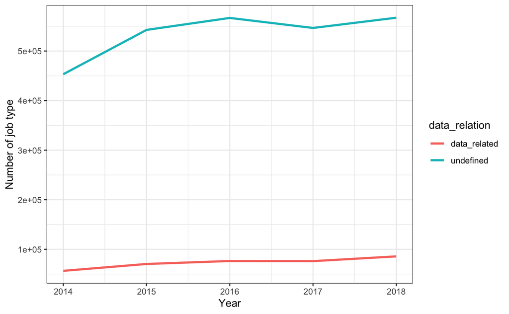

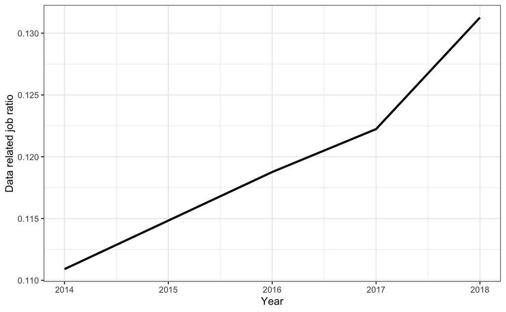

# top analysis

## high level in top

`r`r highlevel_in_top <- DATA %>% filter(employer_name %in% soc_top) %>% group_by(year, job_level) %>% summarise(level_num = n())

highlevel_in_top

| year | job_level | level_num |
| --- | --- | --- |
| 2014 | high level | 17809 |
| 2014 | undefined | 59978 |
| 2015 | high level | 25993 |
| 2015 | undefined | 79925 |
| 2016 | high level | 22406 |
| 2016 | undefined | 70229 |
| 2017 | high level | 20445 |
| 2017 | undefined | 61097 |
| 2018 | high level | 22451 |
| 2018 | undefined | 62661 |

`r`r ggplot(highlevel_in_top)+ geom_line(aes(x=year,y=level_num,color=job_level), size = 1.05)+ theme_bw()+ labs(x=, y=of job level in top)

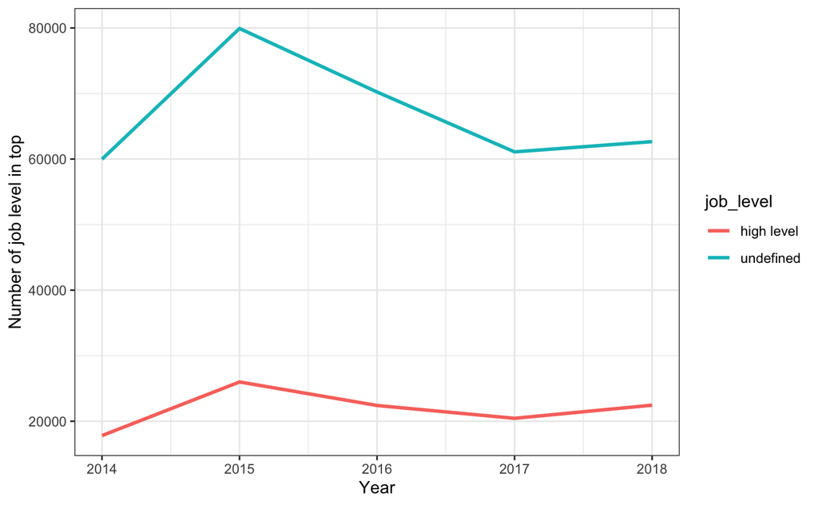

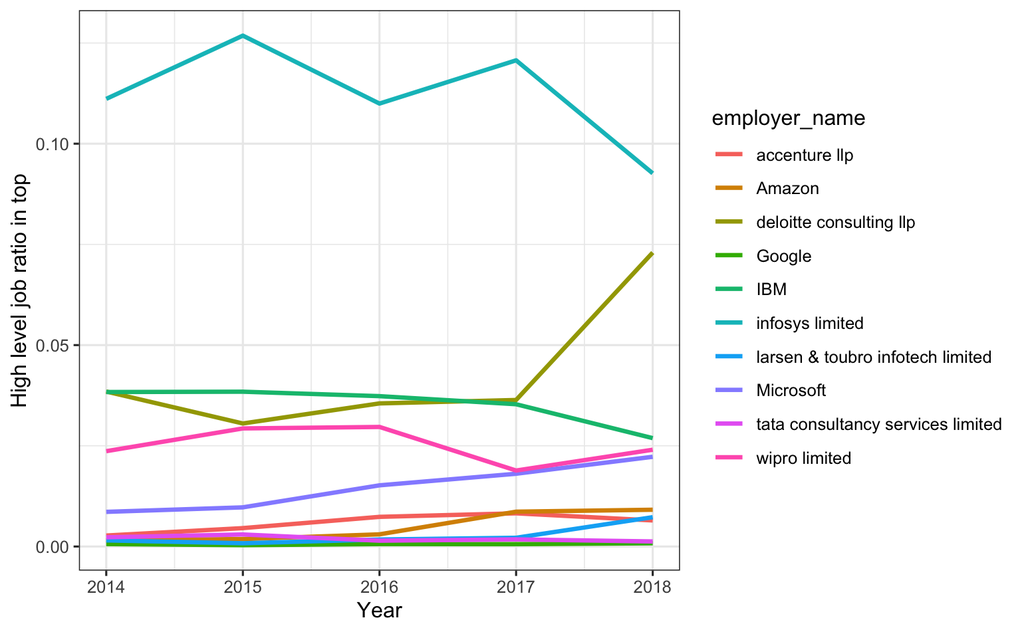

## data related in top

`r`r data_related_in_top <- DATA %>% filter(employer_name %in% soc_top) %>% group_by(year, data_relation) %>% summarise(type_sum = n())

data_related_in_top

| year | data_relation | type_sum |
| --- | --- | --- |
| 2014 | data_related | 4720 |
| 2014 | undefined | 73067 |
| 2015 | data_related | 7521 |
| 2015 | undefined | 98397 |
| 2016 | data_related | 6408 |
| 2016 | undefined | 86227 |
| 2017 | data_related | 6320 |
| 2017 | undefined | 75222 |
| 2018 | data_related | 7800 |
| 2018 | undefined | 77312 |

`r`r ggplot(data_related_in_top)+ geom_line(aes(x=year,y=type_sum,color=data_relation), size = 1.05)+ theme_bw()+ labs(x=, y=of job type)

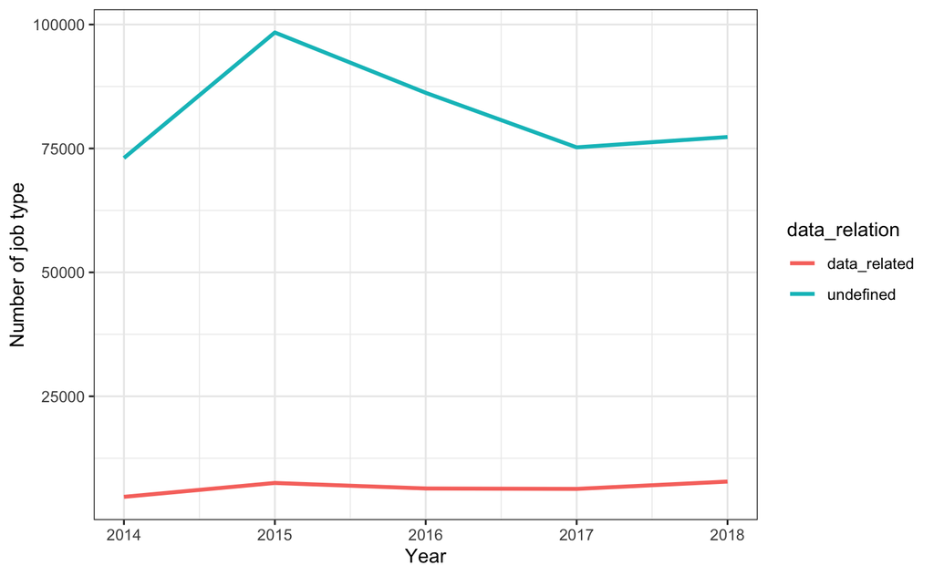

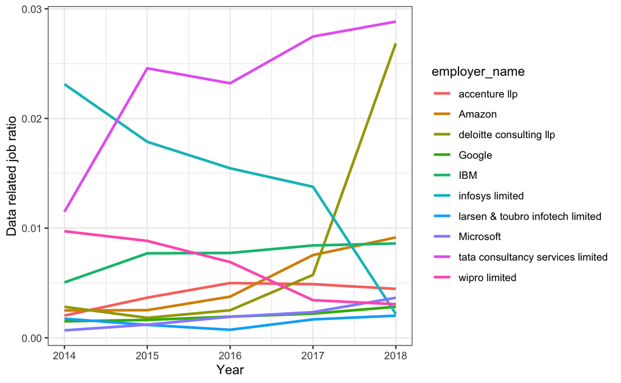

# top tech analysis

`r`r

# mutate(employer_name = ifelse(str_detect(employer_name,‘apple inc’), ‘Apple’,

# ifelse(str_detect(employer_name,‘microsoft’), ‘Microsoft’,

# ifelse(str_detect(employer_name,‘amazon’),‘Amazon’,

# ifelse(str_detect(employer_name,‘cisco sys’),‘Cisco’,

# ifelse(str_detect(employer_name,‘facebook’),‘Facebook’,

# ifelse(str_detect(employer_name,‘google’),‘Google’,

# ifelse(str_detect(employer_name, ‘ibm’),‘IBM’,‘no’))))))))

## high level in top tech

`r`r highlevel_in_top_tech <- DATA %>% filter(employer_name %in% soc_top_tech) %>% group_by(year, job_level) %>% summarise(level_num = n())

highlevel_in_top_tech

[output not shown]

`r`r ggplot(highlevel_in_top_tech)+ geom_line(aes(x=year,y=level_num,color=job_level), size = 1.05)+ theme_bw()+ labs(x=, y=of job level in top)

[figure not shown]

[figure not shown]

## data related in top tech

`r`r data_related_in_top_tech <- DATA %>% filter(employer_name %in% soc_top_tech) %>% select(year,job_title,data_relation) %>% group_by(year, data_relation) %>% summarise(type_sum = n())

data_related_in_top_tech

[output not shown]

`r`r ggplot(data_related_in_top_tech)+ geom_line(aes(x=year,y=type_sum,color=data_relation), size = 1.05)+ theme_bw()+ labs(x=, y=of job type)

[figure not shown]

[figure not shown]

#SDE

`r`r sde_related <- DATA %>% group_by(year, sde_relation) %>% summarise(type_sum = n())

sde_related r

ggplot(sde_related)+ geom_line(aes(x=year,y=type_sum,color=sde_relation), size = 1.05)+ theme_bw()+ labs(x=, y=of job type)

| year | sde_relation | type_sum |
| --- | --- | --- |
| 2014 | sde_related | 253054 |
| 2014 | undefined | 256675 |
| 2015 | sde_related | 312451 |
| 2015 | undefined | 300574 |
| 2016 | sde_related | 324980 |
| 2016 | undefined | 318231 |
| 2017 | sde_related | 307613 |
| 2017 | undefined | 315075 |
| 2018 | sde_related | 306071 |
| 2018 | undefined | 346897 |

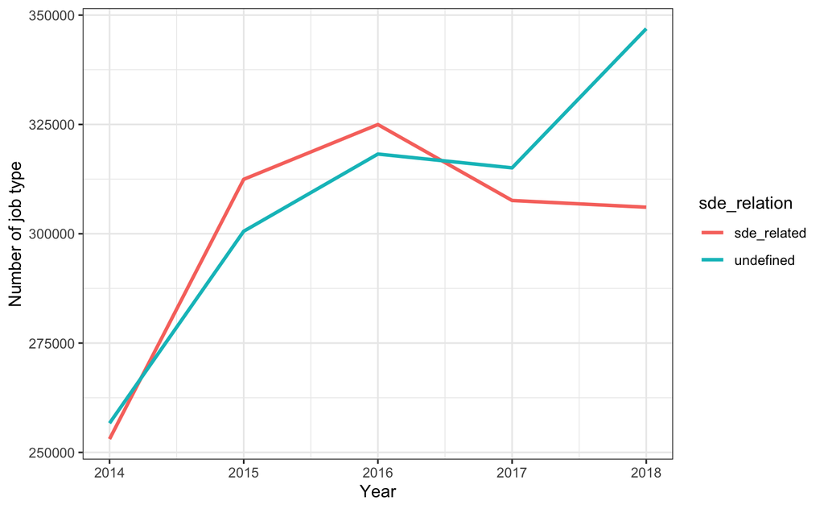

`r`r #+coord_cartesian(ylim = c(0,400000))